# 240924_MESA_AGB_CNO

```python
#WD 1856 proposal
#2.0 Msun star during the AGB Phase of Evolution
#subsolar metallicity (-0.1 or -0.2)
import read_mist_models
import mesa_reader as mr
import numpy as np
import matplotlib.pyplot as plt
%matplotlib inline
import smplotlib
```

We want to explore the star at its largest size, which is the during the thermally pulsating asymptotic giant branch, also known as the TPAGB.

We will investigate surface abundances using two files. File one (f1) will be a low-metallicity ([Feh]=-0.1) MIST model of a 2.0 Msun star obtained here: https://waps.cfa.harvard.edu/MIST/interp_tracks.html

```python
f1 = read_mist_models.EEPCMD('MIST_eep_66f385bcce935/0020000M.track.eep.cmd')
eep = read_mist_models.EEP('MIST_eep_66f385bcce935/0020000M.track.eep')
```

```
Reading in: MIST_eep_66f385bcce935/0020000M.track.eep.cmd
Reading in: MIST_eep_66f385bcce935/0020000M.track.eep
```

File two (f2) is one of the many AGB stellar tracks ran by Meridith Joyce, which can be found here: https://zenodo.org/records/11282597

Some notes: The tar.gz archive files labeled with a string of the form "AGB_to_end_M1.XX_y-fixed.tar.gz" include all models having a mass beginning with 1 (1.00, 1.10, 1.20, etc) and adopting the fixed helium assumption.

Anything that starts with "history" and ends with ".data" is an evolutionary track. Tracks that have "_p3" are the third phase: AGB to end (or failure of the model) and these files are large.

In the file name, the two-decimal number after m, four-decimal number after z and 3-decimal number after y encode the evolutionary track's initial mass, initial metallicity (Z) and initial helium abundance (Y), respectively. In cases where there is no y value provided, the helium abundance is fixed as described in the paper. I checked both the results with the fixed and the varied Y value and it made negligible difference.

```python
f2=mr.MesaData('AGB_to_end_M2.XX_y-fixed/history_m2.00_z0.0100_eta0.01_drag-on_seismic_p3.data')
#f2=mr.MesaData('AGB_to_end_M2.XX_y-varied/history_m2.00_z0.0100_y0.270_eta0.01_yi-on_seismic_p3.data')
```

Note that our two files are close matches in the HR Diagram.

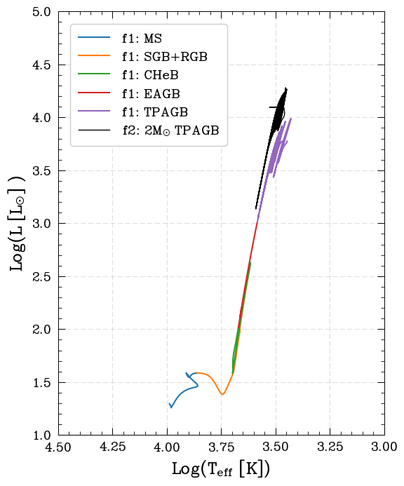

```python
fig, ax = plt.subplots(figsize = (6,8))

# Following the FSPS notation, PMS:-1 ; MS:0 ; SGB+RGB:2 ; CHeB:3 ; EAGB:4 ; TPAGB:5 ; post-AGB:6 ; WR:9
plt.plot(f1.eepcmds['log_Teff'][eep.eeps['phase']==0],f1.eepcmds['log_L'][eep.eeps['phase']==0],label='f1: MS')
plt.plot(f1.eepcmds['log_Teff'][eep.eeps['phase']==2],f1.eepcmds['log_L'][eep.eeps['phase']==2],label='f1: SGB+RGB')
plt.plot(f1.eepcmds['log_Teff'][eep.eeps['phase']==3],f1.eepcmds['log_L'][eep.eeps['phase']==3],label='f1: CHeB')
plt.plot(f1.eepcmds['log_Teff'][eep.eeps['phase']==4],f1.eepcmds['log_L'][eep.eeps['phase']==4],label='f1: EAGB')
plt.plot(f1.eepcmds['log_Teff'][eep.eeps['phase']==5],f1.eepcmds['log_L'][eep.eeps['phase']==5],label='f1: TPAGB')
#plt.plot(eepcmd.eepcmds['log_Teff'][eep.eeps['phase']==6],eepcmd.eepcmds['log_L'][eep.eeps['phase']==6],label='post-AGB')

ax.plot(f2.log_Teff, f2.log_L, label='f2: 2M$_{\odot}$ TPAGB', c = 'black',lw=1.0)
ax.legend(loc = 'best', fontsize = 15);

ax.set_ylabel(r'Log(L [L$_{\odot}$] )', fontsize=20)
ax.set_xlabel(r'Log(T$_{\rm eff}$ [K])', fontsize=20)
ax.invert_xaxis()                                         # inverts x-axis
ax.set_ylim(1,5.0)
ax.set_xlim(4.5,3.0)
ax.tick_params(axis='both', which='major', labelsize=15)  # changes the tick label size
plt.grid(alpha=0.25)
plt.legend(frameon=True,fontsize=16)
```

Below is a list of all the properties that we could plot for the f2 track.

```python
f2.bulk_names
```

```
('model_number',
 'num_zones',
 'star_age',
 'log_dt',
 'star_mass',
 'log_xmstar',
 'log_abs_mdot',
 'mass_conv_core',
 'conv_mx1_top',
 'conv_mx1_bot',
 'conv_mx2_top',
 'conv_mx2_bot',
 'mx1_top',
 'mx1_bot',
 'mx2_top',
 'mx2_bot',
 'cz_logRho',
 'cz_logP',
 'log_LH',
 'log_LHe',
 'log_LZ',
 'log_Lnuc',
 'pp',
 'cno',
 'tri_alpha',
 'epsnuc_M_1',
 'epsnuc_M_2',
 'epsnuc_M_3',
 'epsnuc_M_4',
 'epsnuc_M_5',
 'epsnuc_M_6',
 'epsnuc_M_7',
 'epsnuc_M_8',
 'he_core_mass',
 'co_core_mass',
 'one_core_mass',
 'fe_core_mass',
 'neutron_rich_core_mass',
 'log_Teff',
 'log_L',
```

[output cut: 23 more lines]

```
 'phase_of_evolution',
 'num_retries',
 'num_iters',
 'nu_radial_0',
 'nu_radial_1',
 'nu_radial_2',
 'nu_radial_3',
 'nu_radial_4',
 'nu_radial_5',
 'nu_radial_6',
 'nu_radial_7',
 'nu_radial_8',
 'nu_radial_9',
 'gamma1_top',
 'gamma1_bottom')
```

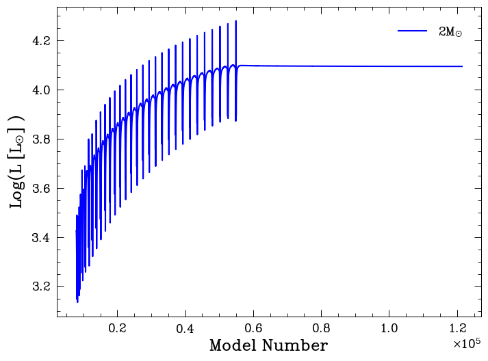

```python
fig, ax = plt.subplots(figsize = (8,6))

ax.plot(f2.model_number, f2.log_L, label='2M$_{\odot}$', c = 'b')
ax.legend(loc = 'best', fontsize = 15);

ax.set_ylabel(r'Log(L [L$_{\odot}$] )', fontsize=20)
ax.set_xlabel('Model Number', fontsize=20)

ax.tick_params(axis='both', which='major', labelsize=15)  # changes the tick label size

# plt.savefig('L_time_5msun_3fos.png', bbox_inches='tight')   #uncomment this line to save
```

Note that the radius grows larger with each pulse.

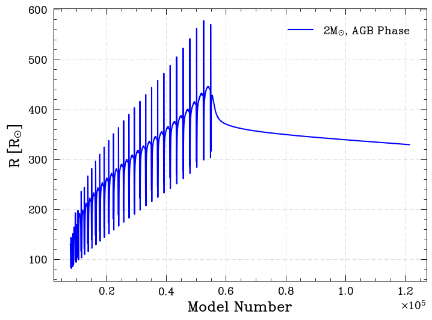

```python
fig, ax = plt.subplots(figsize = (8,6))

ax.plot(f2.model_number, 10**f2.log_R, label='2M$_{\odot}$, AGB Phase', c = 'b')
ax.legend(loc = 'best', fontsize = 15);
ax.set_ylabel(r'R [R$_{\odot}$] ', fontsize=20)
ax.set_xlabel('Model Number', fontsize=20)
ax.tick_params(axis='both', which='major', labelsize=15)  # changes the tick label size
plt.grid(alpha=0.25)
```

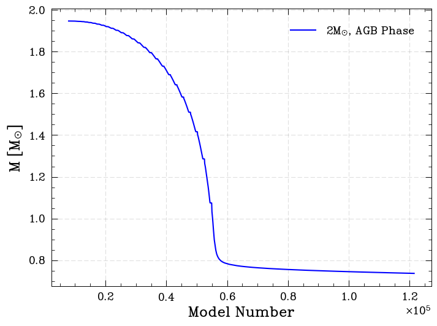

```python
fig, ax = plt.subplots(figsize = (8,6))

ax.plot(f2.model_number, f2.star_mass, label='2M$_{\odot}$, AGB Phase', c = 'b')
ax.legend(loc = 'best', fontsize = 15);
ax.set_ylabel(r'M [M$_{\odot}$] ', fontsize=20)
ax.set_xlabel('Model Number', fontsize=20)
ax.tick_params(axis='both', which='major', labelsize=15)  # changes the tick label size
plt.grid(alpha=0.25)
```

The f2 file only has two surface abundances within the CNO umbrella saved therein. Let's plot them and then see how they compare to the MIST values.

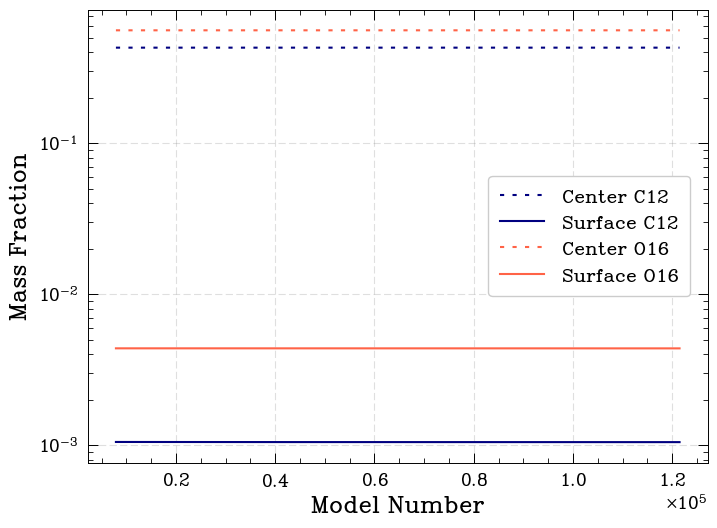

```python
fig, ax = plt.subplots(figsize = (8,6))

ax.plot(f2.model_number, f2.center_c12,label='Center C12',ls='dotted',c='navy')
ax.plot(f2.model_number, f2.surface_c12,label='Surface C12',c='navy')
ax.plot(f2.model_number, f2.center_o16,label='Center O16',ls='dotted',c='tomato')
ax.plot(f2.model_number, f2.surface_o16,label='Surface O16',c='tomato')

ax.legend(loc = 'best', fontsize = 15);

ax.set_xlabel('Model Number', fontsize=20)
ax.set_ylabel('Mass Fraction', fontsize=20)
ax.tick_params(axis='both', which='major', labelsize=15)  # changes the tick label size
plt.legend(frameon=True,fontsize=16)
plt.yscale('log')
plt.grid(alpha=0.25)
```

```python
f2.surface_c12[len(f2.surface_c12)-1]
```

```
0.0010508210390359305
```

```python
eep.eeps['surface_c12'][1709]
```

```
0.0010721446544306357
```

```python
f2.surface_o16[len(f2.surface_o16)-1]
```

```
0.004386037240310043
```

```python
eep.eeps['surface_o16'][1709]
```

```
0.0050457229925589975
```

Yay, the surface abundances match pretty well. That is what I was hoping for. This indicates to me we are fairly safe to use MIST values in determining other surface abundances. Many more surface abundances are provided in the MIST model. Here are the ones Syndey and Andrew asked for:

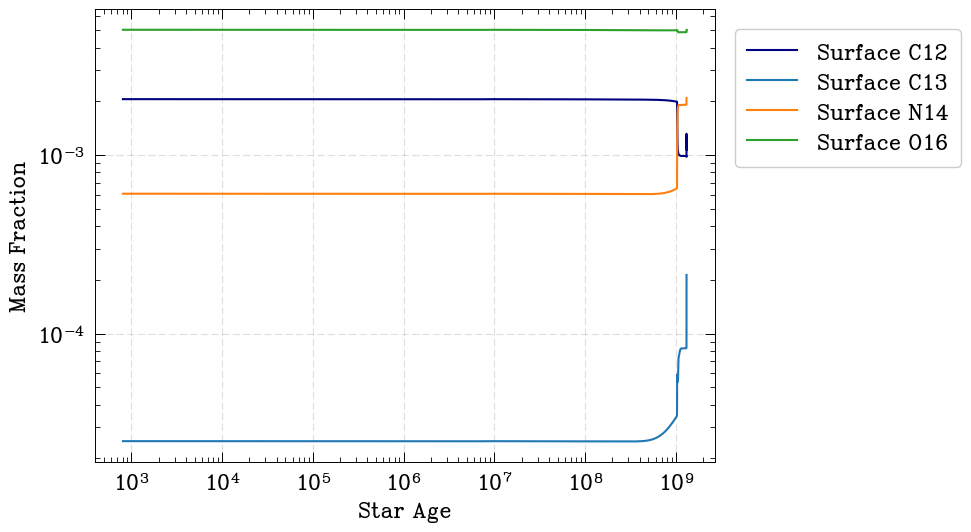

```python
plt.rcParams.update({'font.size': 18})
plt.figure(figsize=(8, 6))

plt.plot(eep.eeps['star_age'], eep.eeps['surface_c12'], label='Surface C12',c='navy')
plt.plot(eep.eeps['star_age'], eep.eeps['surface_c13'], label='Surface C13')
plt.plot(eep.eeps['star_age'], eep.eeps['surface_n14'], label='Surface N14')
plt.plot(eep.eeps['star_age'], eep.eeps['surface_o16'], label='Surface O16')

plt.xlabel('Star Age')
plt.ylabel('Mass Fraction')
plt.xscale('log')
plt.yscale('log')
plt.legend(loc='upper left', bbox_to_anchor=(1, 1),frameon=True)
plt.grid(alpha=0.25)
```

And here are a few others!

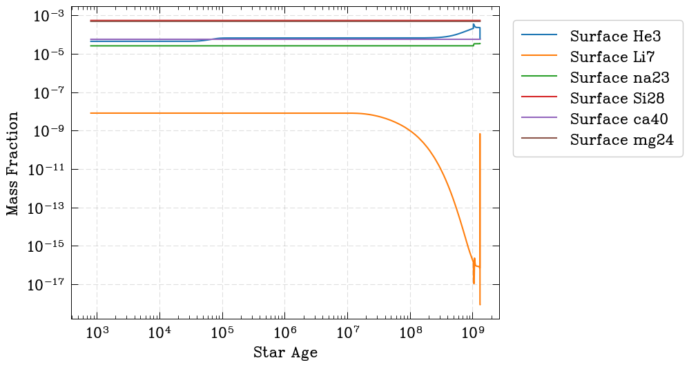

```python
plt.rcParams.update({'font.size': 18})
plt.figure(figsize=(8, 6))

plt.plot(eep.eeps['star_age'], eep.eeps['surface_he3'], label='Surface He3')
plt.plot(eep.eeps['star_age'], eep.eeps['surface_li7'], label='Surface Li7')
plt.plot(eep.eeps['star_age'], eep.eeps['surface_na23'], label='Surface na23')
plt.plot(eep.eeps['star_age'], eep.eeps['surface_si28'], label='Surface Si28')
plt.plot(eep.eeps['star_age'], eep.eeps['surface_ca40'], label='Surface ca40')
plt.plot(eep.eeps['star_age'], eep.eeps['surface_mg24'], label='Surface mg24')
plt.xlabel('Star Age')
plt.ylabel('Mass Fraction')
#plt.axis([1e7, 2.5e9, 1e-6, 3])
plt.xscale('log')
plt.yscale('log')
plt.legend(loc='upper left', bbox_to_anchor=(1, 1),frameon=True)
plt.grid(alpha=0.25)
```